# Why use informative priors?

Steve Simon

April 3, 2017

I’ve been working with some colleagues on accrual models an other than us, there seem to be no others interested in using a fully Bayesian approach to accrual. There are many reasons why you should consider a fully Bayesian approach, but with this program, I want to illustrate just one of these reasons: a fully Bayesian approach to accrual allows you to make reasonable forecasts very early in the trial.

Cosinder a real accrual example described at

http://www.pmean.com/07/CaseStudyOfAccrualPart2.html

and

http://www.pmean.com/07/CaseStudyOfAccrual.html

I will repeat the key details here.

A clinical trial was planned to start on August 28, 2007 and continue until January 31, 2008, for a total of 22 weeks. The researcher thought it would be reasonable to set the median recruitment rate at three patients per week and the worst case scenario would be recruiting only two patients per week. There is a recommended question that you should ask when eliciting a recruitment rate: “On a scale of 1 to 10, how confident are you in this estimate?” The client said “5” with no hesitation or uncertainty in his voice.

This leads to a gamma(33, 11) prior distribution.

On the first week, one patient (not three) arrived. In weeks 2, 3, and 4, no patients arrived. Thankfully on week 5, three patients arrived. On week 6 one more patient arrived.

So clearly, we are behind schedule. How bad is it?

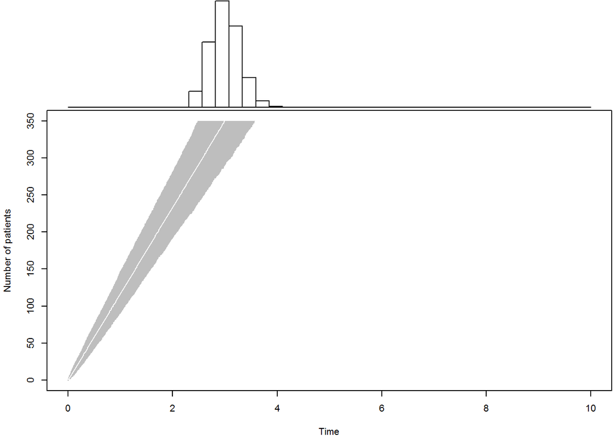

```r
duration.plot <- function(n,T,P,m,tm,B=1000,Tmax=2*T,sample.paths=0) {
# n is the target sample size
# T is the target completion time
# P is the prior certainty (0 <= P <= 1)
# m is the sample observed to date
# tm is the time to date
# B is the number of simulated duration times
# Tmax is the upper limit on the time axis of the graph
#
# set P to zero for a non-informative prior
# set m and tm to zero if no data has been accumulated yet.

  k <- n*P+m
  V <- T*P+tm
  theta <- 1/rgamma(B,shape=k,rate=V)
  simulated.duration <- matrix(NA,nrow=n-m,ncol=B)

  for (i in 1:B) {
    wait <- rexp(n-m,1/theta[i])
    simulated.duration[,i] <- tm+cumsum(wait)
  }

  lcl <- apply(simulated.duration,1,quantile,probs=0.025)
  mid <- apply(simulated.duration,1,quantile,probs=0.500)
  ucl <- apply(simulated.duration,1,quantile,probs=0.975)

  layout(matrix(c(1,2,2,2)))
  par(mar=c(0.1,4.1,0.1,0.1))
  duration.hist <- cut(simulated.duration[n-m,],
    seq(0,Tmax,length=40))
  barplot(table(duration.hist),horiz=FALSE,
    axes=FALSE,xlab=" ",ylab=" ",space=0,
    col="white",names.arg=rep(" ",39))

  par(mar=c(4.1,4.1,0.1,0.1))
  plot(c(0,Tmax),c(0,n),xlab="Time",
    ylab="Number of patients",type="n")
  polygon(c(lcl,rev(ucl)),c((m+1):n,n:(m+1)),
    density=-1,col="gray",border=NA)
  lines(mid,(m+1):n,col="white")
  segments(0,0,tm,m)

  while (sample.paths>0) {
    lines(simulated.duration[,sample.paths],(m+1):n)
    sample.paths <- sample.paths-1
  }

  pctiles <- matrix(NA,nrow=2,ncol=3)
  dimnames(pctiles) <- list(c("Waiting time","Trial duration")
    ,c("2.5%","50%","97.5%"))
  pctiles[1,] <- 1/qgamma(c(0.975,0.5,0.025),shape=k,rate=V)
  pctiles[2,1] <- lcl[n-m]
  pctiles[2,2] <- mid[n-m]
  pctiles[2,3] <- ucl[n-m]
  list(pct=pctiles,sd=simulated.duration)
}

p0 <- duration.plot(n=350,T=3,P=0.5,m= 0,tm= 0,Tmax=10)
```

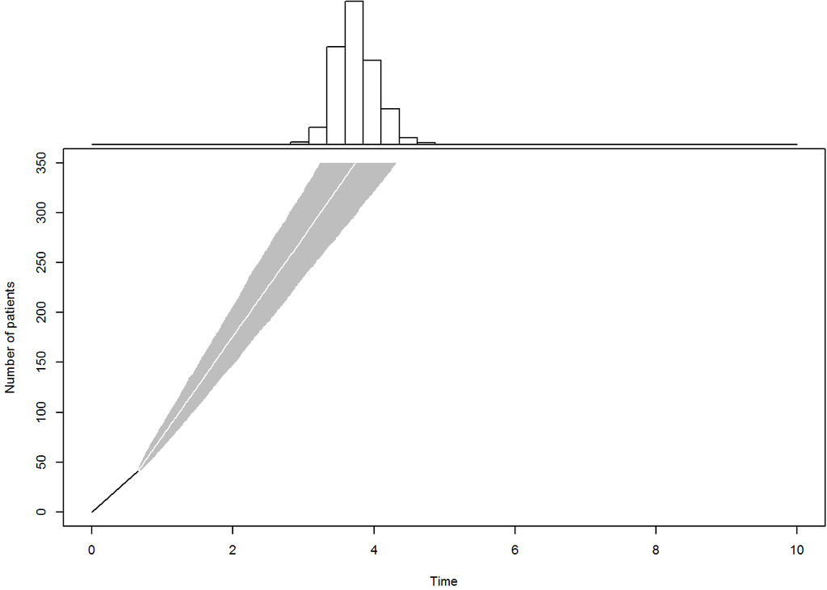

```r
p1 <- duration.plot(n=350,T=3,P=0.5,m=41,tm=239/365,Tmax=10)
```

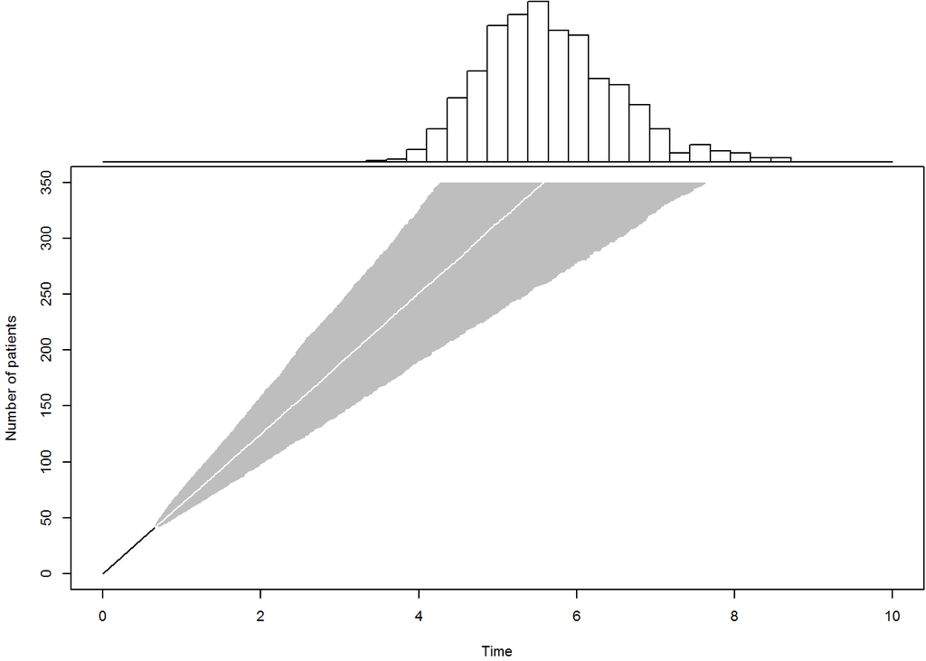

```r
p2 <- duration.plot(n=350,T=3,P=0, m=41,tm=239/365,Tmax=10)
```

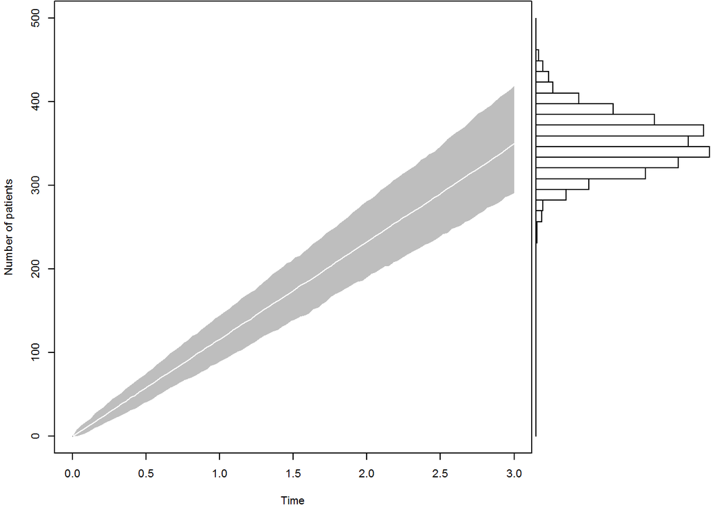

```r
accrual.plot <- function(n,T,P,m,tm,B=1000,nmax=2*n,sample.paths=0) {
# n is the target sample size
# T is the target completion time
# P is the prior certainty (0 <= P <= 1)
# m is the sample observed to date
# tm is the time to date
# B is the number of simulated accrual times
# nmax is the upper limit on the sample size axis of the graph
#
# set P to zero for a non-informative prior
# set m and tm to zero if no data has been accumulated yet.

  k <- n*P+m
  V <- T*P+tm
  theta <- 1/rgamma(B,shape=k,rate=V)
  simulated.duration <- matrix(NA,nrow=nmax-m,ncol=B)

  for (i in 1:B) {
    wait <- rexp(nmax-m,1/theta[i])
    simulated.duration[,i] <- tm+cumsum(wait)
  }

  tlist <- seq(tm,T,length=100)
  accrual.count <- function(x,t) {m+sum(x<=t)}
  simulated.accrual <- matrix(NA,nrow=100,ncol=B)

  for (i in 1:100) {
    time <- tlist[i]
    simulated.accrual[i,] <- apply(simulated.duration,2,
      accrual.count,t=time)
  }

  lcl <- apply(simulated.accrual,1,quantile,probs=0.025)
  mid <- apply(simulated.accrual,1,quantile,probs=0.500)
  ucl <- apply(simulated.accrual,1,quantile,probs=0.975)

  layout(matrix(c(2,2,2,1),nrow=1))
  par(mar=c(4.1,0.1,0.1,0.1))
  accrual.hist <- cut(simulated.accrual[100,],
    seq(0,nmax,length=40))
  barplot(table(accrual.hist),horiz=TRUE,
    axes=FALSE,xlab=" ",ylab=" ",space=0,
    col="white",names.arg=rep(" ",39))

  par(mar=c(4.1,4.1,0.1,0.1))
  plot(c(0,T),c(0,nmax),xlab="Time",
    ylab="Number of patients",type="n")
  polygon(c(tlist,rev(tlist)),c(lcl,rev(ucl)),
    density=-1,col="gray",border=NA)
  lines(tlist,mid,col="white")
  segments(0,0,tm,m)

  while (sample.paths>0) {
    lines(tlist,simulated.accrual[,sample.paths])
    sample.paths <- sample.paths-1
  }

  pctiles <- matrix(NA,nrow=2,ncol=3)
  dimnames(pctiles) <- list(c("Waiting time",
    "Trial accrual"),c("2.5%","50%","97.5%"))
  pctiles[1,] <- 1/qgamma(c(0.975,0.5,0.025),shape=k,rate=V)
  pctiles[2,1] <- lcl[100]
  pctiles[2,2] <- mid[100]
  pctiles[2,3] <- ucl[100]
  list(pct=pctiles,sa=simulated.accrual)
}

# Run three test examples from the original webpage.

d0 <- accrual.plot(n=350,T=3,P=0.5,m= 0,tm= 0,nmax=500)
```

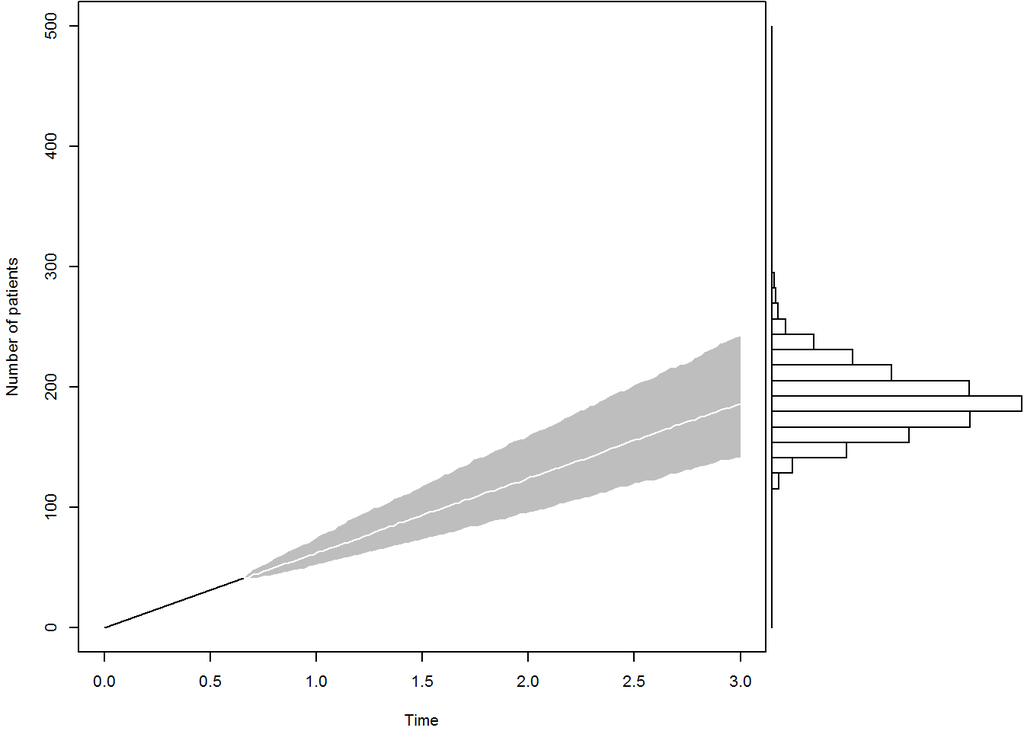

```r
d1 <- accrual.plot(n=350,T=3,P=0, m=41,tm=239/365,nmax=500)
```

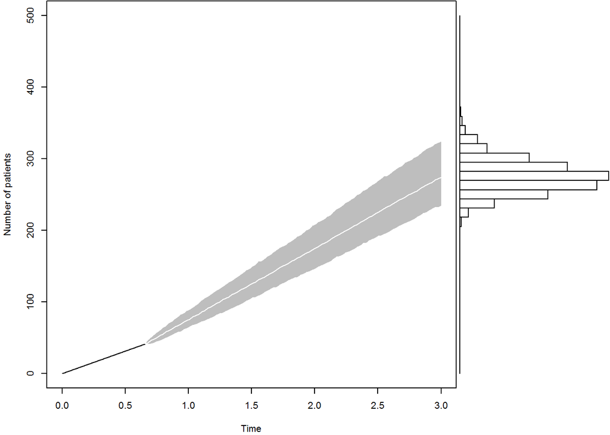

```r
d2 <- accrual.plot(n=350,T=3,P=0.5,m=41,tm=239/365,nmax=500)
```

That’s a relief that my code from 2008 still works.

So what does the prior prediction look like for 66 patients in 22 weeks and a prior strength of 0.5, which corresponds to a gamma(33, 11)? I am including a red reference line for the expected duration of 22 weeks and a blue reference line for the expected worst case duration of 33 weeks.

```r
x0 <- duration.plot(n=66, T=22, P=0.5, m=0, tm=0)
print(x0$pct)
```

```
##                      2.5%        50%     97.5%
## Waiting time    0.2435005  0.3367285  0.484247
## Trial duration 15.0411498 22.2856425 34.452221
```

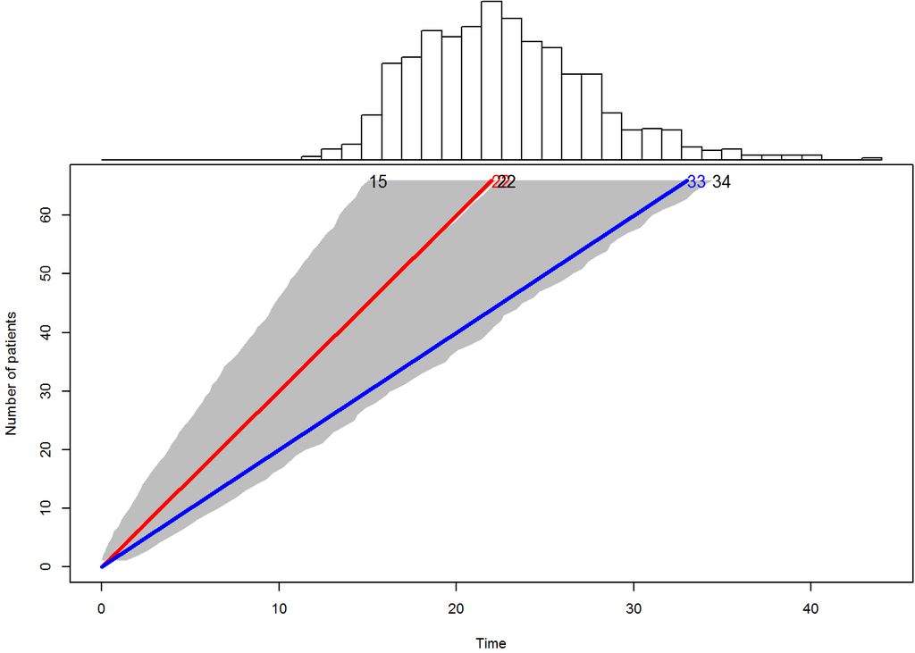

```r
segments(0,0, 22, 66, col="red", lwd=3)
segments(0,0, 33, 66, col="blue", lwd=3)
text(22, 66, "22", col="red", cex=1.25, adj=0)
text(33, 66, "33", col="blue", cex=1.25, adj=0)
text(x0$pct[2, ], 66, round(x0$pct[2, ]), cex=1.25, adj=0)
```

```r
# week=1, total patients=1
x1 <- duration.plot(n=66, T=22, P=0.5, m=1, tm=1)
print(x1$pct)
```

```
##                      2.5%        50%     97.5%
## Waiting time    0.2589317  0.3564294  0.509641
## Trial duration 16.1396133 23.7711399 35.703493
```

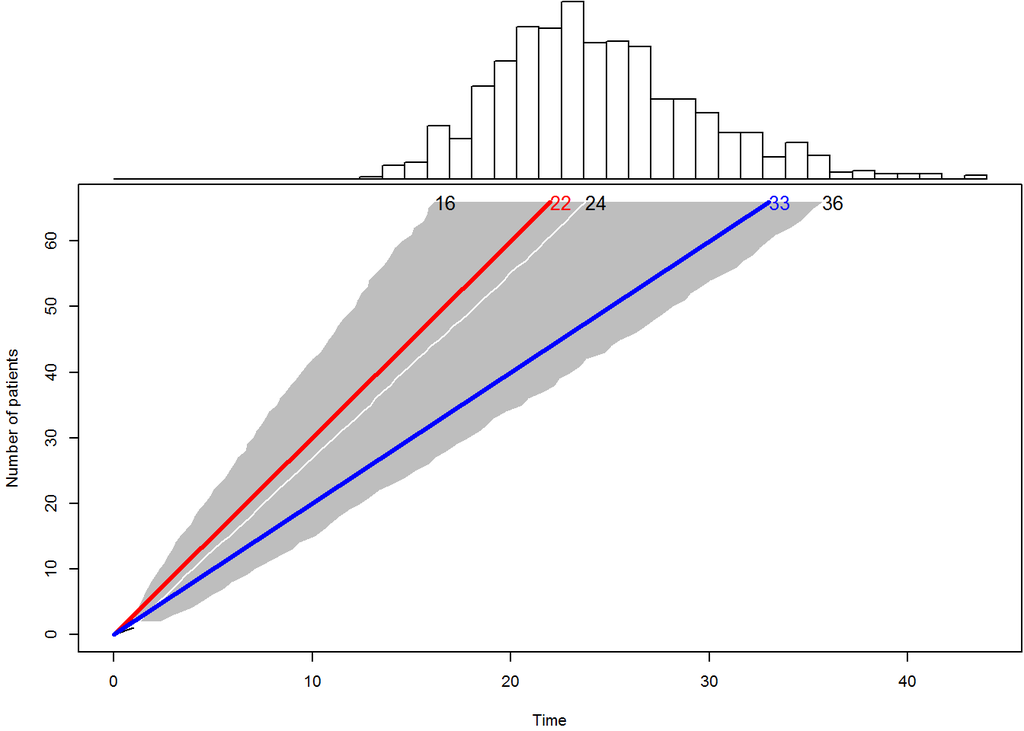

```r
segments(0,0, 22, 66, col="red", lwd=3)
segments(0,0, 33, 66, col="blue", lwd=3)
text(22, 66, "22", col="red", cex=1.25, adj=0)
text(33, 66, "33", col="blue", cex=1.25, adj=0)
text(x1$pct[2, ], 66, round(x1$pct[2, ]), cex=1.25, adj=0)
```

```r
# week=2, total patients=1
x2 <- duration.plot(n=66, T=22, P=0.5, m=1, tm=2)
print(x2$pct)
```

```
##                      2.5%        50%     97.5%
## Waiting time    0.2805093  0.3861319  0.552111
## Trial duration 18.7348329 26.9535270 40.278018
```

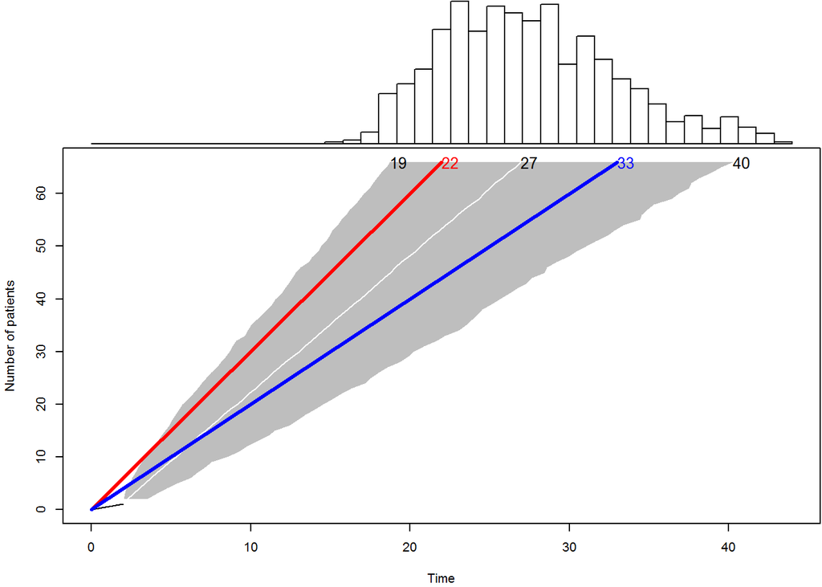

```r
segments(0,0, 22, 66, col="red", lwd=3)
segments(0,0, 33, 66, col="blue", lwd=3)
text(22, 66, "22", col="red", cex=1.25, adj=0)
text(33, 66, "33", col="blue", cex=1.25, adj=0)
text(x2$pct[2, ], 66, round(x2$pct[2, ]), cex=1.25, adj=0)
```

```r
# week=3, total patients=1
x3 <- duration.plot(n=66, T=22, P=0.5, m=1, tm=3)
print(x3$pct)
```

```
##                     2.5%        50%      97.5%
## Waiting time    0.302087  0.4158343  0.5945811
## Trial duration 20.875909 30.1598585 44.0350564
```

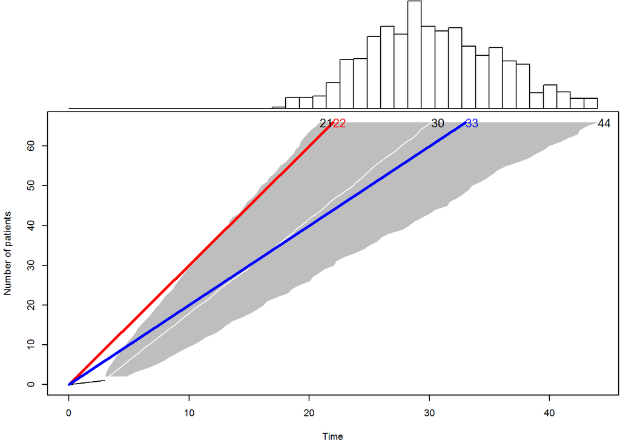

```r
segments(0,0, 22, 66, col="red", lwd=3)
segments(0,0, 33, 66, col="blue", lwd=3)
text(22, 66, "22", col="red", cex=1.25, adj=0)
text(33, 66, "33", col="blue", cex=1.25, adj=0)
text(x3$pct[2, ], 66, round(x3$pct[2, ]), cex=1.25, adj=0)
```

```r
# week=4, total patients=1
x4 <- duration.plot(n=66, T=22, P=0.5, m=1, tm=4)
print(x4$pct)
```

```
##                      2.5%        50%      97.5%
## Waiting time    0.3236646  0.4455368  0.6370512
## Trial duration 23.8889106 32.3938367 47.7430958
```

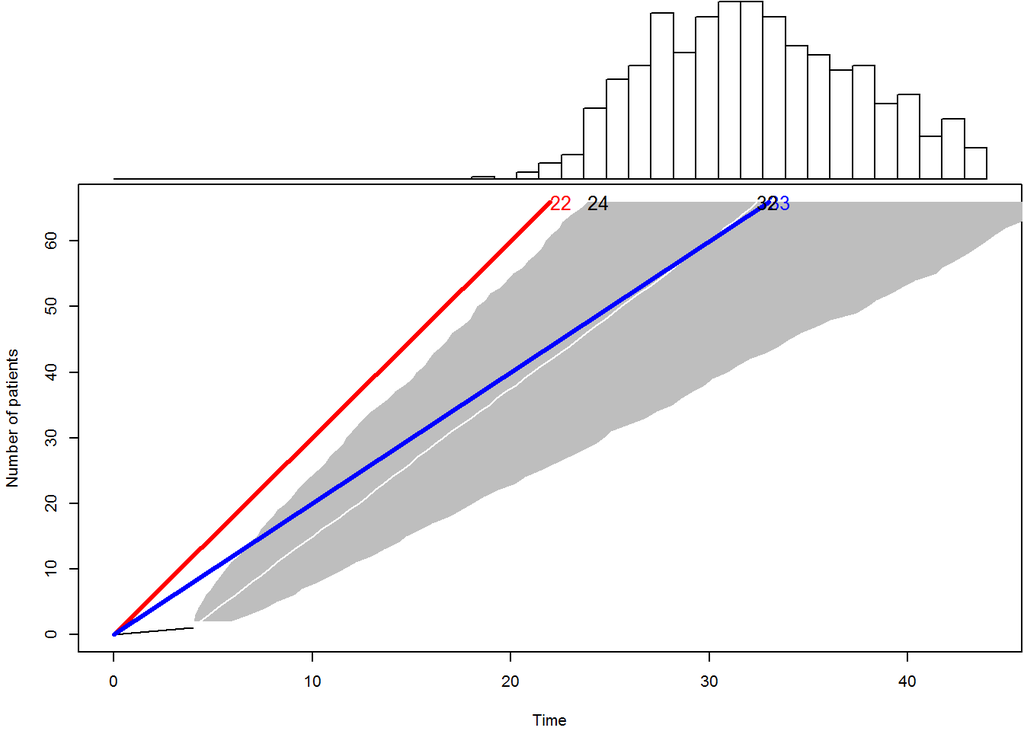

```r
segments(0,0, 22, 66, col="red", lwd=3)
segments(0,0, 33, 66, col="blue", lwd=3)
text(22, 66, "22", col="red", cex=1.25, adj=0)
text(33, 66, "33", col="blue", cex=1.25, adj=0)
text(x4$pct[2, ], 66, round(x4$pct[2, ]), cex=1.25, adj=0)
```

```r
# week=5, total patients=4
x5 <- duration.plot(n=66, T=22, P=0.5, m=4, tm=5)
print(x5$pct)
```

```
##                      2.5%        50%      97.5%
## Waiting time    0.3210326  0.4363572  0.6141701
## Trial duration 22.9966763 31.8368072 46.8436458
```

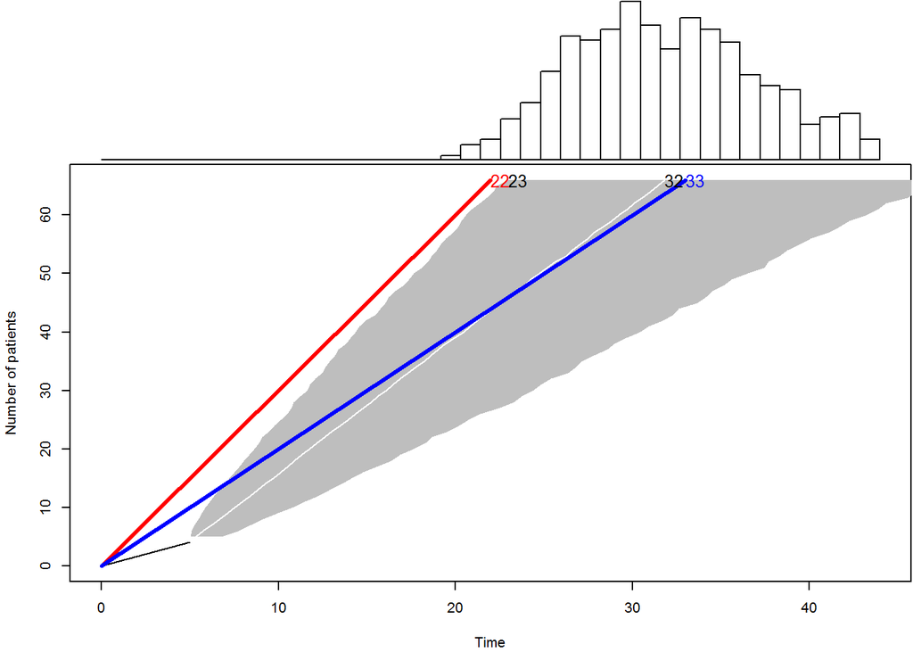

```r
segments(0,0, 22, 66, col="red", lwd=3)
segments(0,0, 33, 66, col="blue", lwd=3)
text(22, 66, "22", col="red", cex=1.25, adj=0)
text(33, 66, "33", col="blue", cex=1.25, adj=0)
text(x5$pct[2, ], 66, round(x5$pct[2, ]), cex=1.25, adj=0)
```

```r
# week=6, total patients=5
x6 <- duration.plot(n=66, T=22, P=0.5, m=5, tm=6)
print(x6$pct)
```

```
##                      2.5%        50%      97.5%
## Waiting time    0.3333358  0.4513211  0.6321803
## Trial duration 24.5883025 33.6886188 48.2790772
```

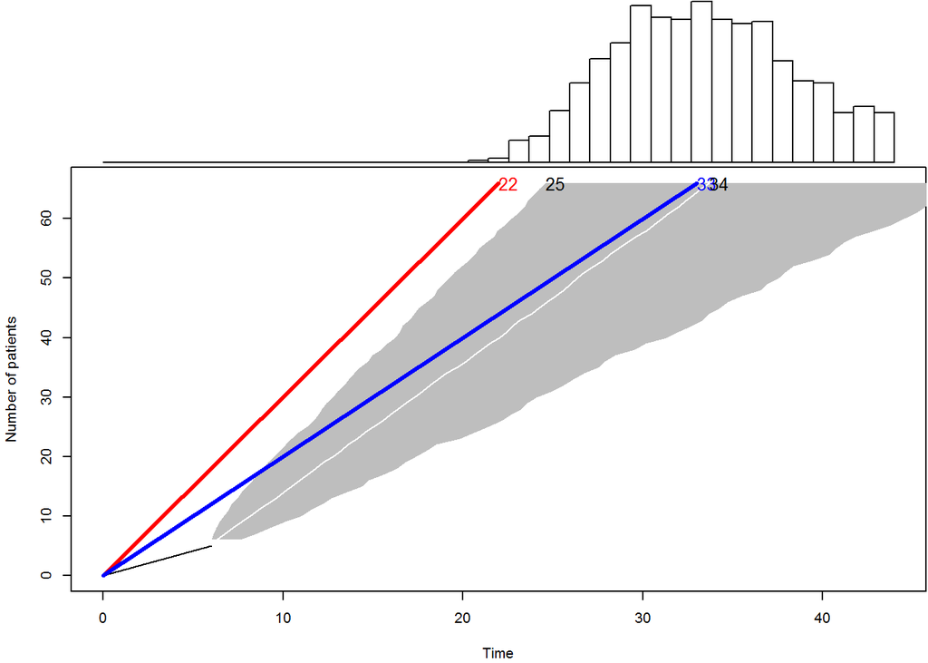

```r
segments(0,0, 22, 66, col="red", lwd=3)
segments(0,0, 33, 66, col="blue", lwd=3)
text(22, 66, "22", col="red", cex=1.25, adj=0)
text(33, 66, "33", col="blue", cex=1.25, adj=0)
text(x6$pct[2, ], 66, round(x6$pct[2, ]), cex=1.25, adj=0)
```

So how would this look if you didn’t like using an informative prior? There are several approaches you can take. The first, outlined on the web at

http://ms.mcmaster.ca/peter/s743/poissonalpha.html

uses the chi-square distribution to get confidence intervals for the Poisson parameter lambda. “Let x be a single observation from a Poisson distribution with mean µ. Then”exact" 95% confidence limits for µ are given by the formula

( qchisq(0.025, 2*x)/2, qchisq(0.975, 2*(x+1))/2 ) "

If x=1, then this works out to be 0.0253178 to 5.5716434. So after one week, you have a fairly wide range of possible rates per week. Divide these rates into 66 patients to get an estimated time range of 11.8456971 weeks (which you round to 12) and 2606.8607535 or 2607 weeks.

You have the same count (one patient) after two weeks, so the 95% confidence interval for rate of 0.0253178 to 5.5716434 still applies except that this is a rate over two weeks. Divide by two and then divide into 66 to get the lower and upper bounds of 23.6913942 and 5213.7215071.

It’s worth a careful appreciation of how bad these intervals are. The upper limit is larger than the lower limit by more than two orders of magnitude.

You can also get an appreciation of how much the informative prior is needed by looking at the Bayesian prediction with a flat prior instead of an informative prior.

```r
# week=1, total patients=1
x1 <- duration.plot(n=66, T=22, P=0, m=1, tm=1, Tmax=10000)
print(x1$pct)
```

```
##                     2.5%       50%      97.5%
## Waiting time    0.271085  1.442695   39.49789
## Trial duration 18.162668 94.285214 3588.90724
```

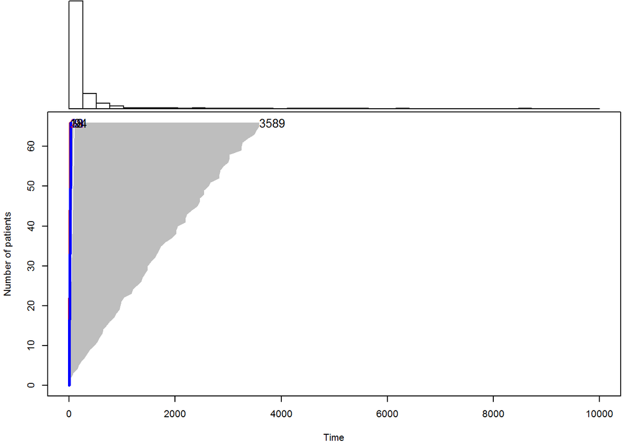

```r
segments(0,0, 22, 66, col="red", lwd=3)
segments(0,0, 33, 66, col="blue", lwd=3)
text(22, 66, "22", col="red", cex=1.25, adj=0)
text(33, 66, "33", col="blue", cex=1.25, adj=0)
text(x1$pct[2, ], 66, round(x1$pct[2, ]), cex=1.25, adj=0)
```

```r
# week=2, total patients=1
x2 <- duration.plot(n=66, T=22, P=0, m=1, tm=2, Tmax=2000)
print(x2$pct)
```

```
##                      2.5%       50%      97.5%
## Waiting time    0.5421701   2.88539   78.99578
## Trial duration 36.8960583 188.13440 4837.33837
```

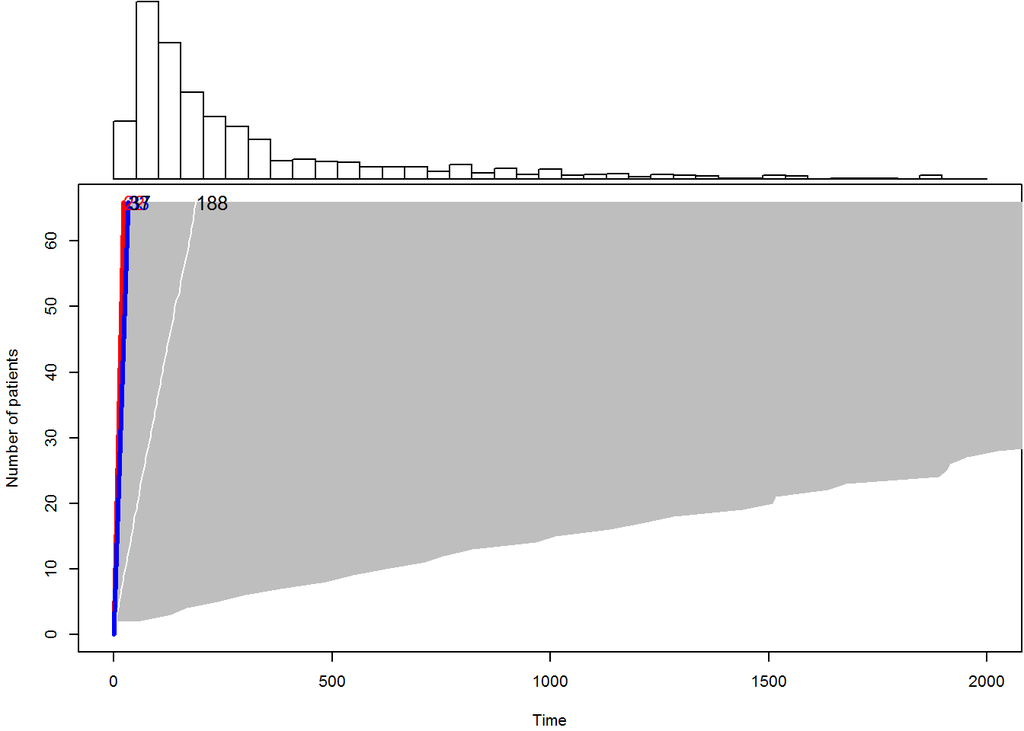

```r
segments(0,0, 22, 66, col="red", lwd=3)
segments(0,0, 33, 66, col="blue", lwd=3)
text(22, 66, "22", col="red", cex=1.25, adj=0)
text(33, 66, "33", col="blue", cex=1.25, adj=0)
text(x2$pct[2, ], 66, round(x2$pct[2, ]), cex=1.25, adj=0)
```

```r
# week=3, total patients=1
x3 <- duration.plot(n=66, T=22, P=0, m=1, tm=3, Tmax=8000)
print(x3$pct)
```

```
##                      2.5%        50%     97.5%
## Waiting time    0.8132551   4.328085  118.4937
## Trial duration 50.6094784 295.626932 5771.5878
```

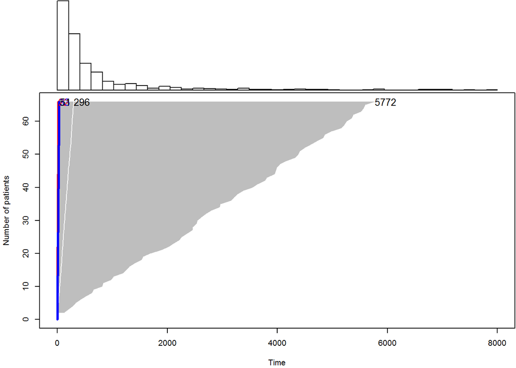

```r
segments(0,0, 22, 66, col="red", lwd=3)
segments(0,0, 33, 66, col="blue", lwd=3)
text(22, 66, "22", col="red", cex=1.25, adj=0)
text(33, 66, "33", col="blue", cex=1.25, adj=0)
text(x3$pct[2, ], 66, round(x3$pct[2, ]), cex=1.25, adj=0)
```

```r
# week=4, total patients=1
x4 <- duration.plot(n=66, T=22, P=0, m=1, tm=4, Tmax=8000)
print(x4$pct)
```

```
##                    2.5%       50%      97.5%
## Waiting time    1.08434   5.77078   157.9916
## Trial duration 72.91118 383.86448 10175.8864
```

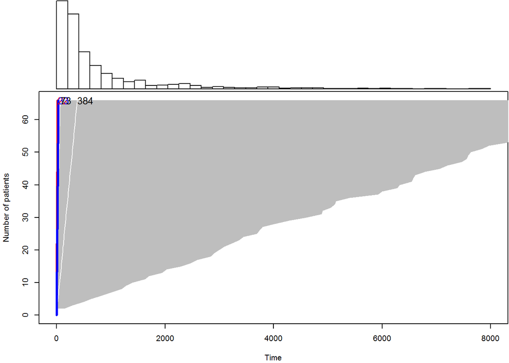

```r
segments(0,0, 22, 66, col="red", lwd=3)
segments(0,0, 33, 66, col="blue", lwd=3)
text(22, 66, "22", col="red", cex=1.25, adj=0)
text(33, 66, "33", col="blue", cex=1.25, adj=0)
text(x4$pct[2, ], 66, round(x4$pct[2, ]), cex=1.25, adj=0)
```

```r
# week=5, total patients=4
x5 <- duration.plot(n=66, T=22, P=0, m=4, tm=5, Tmax=8000)
print(x5$pct)
```

```
##                      2.5%       50%      97.5%
## Waiting time    0.5703028  1.361633   4.587723
## Trial duration 39.5845152 87.033319 267.498362
```

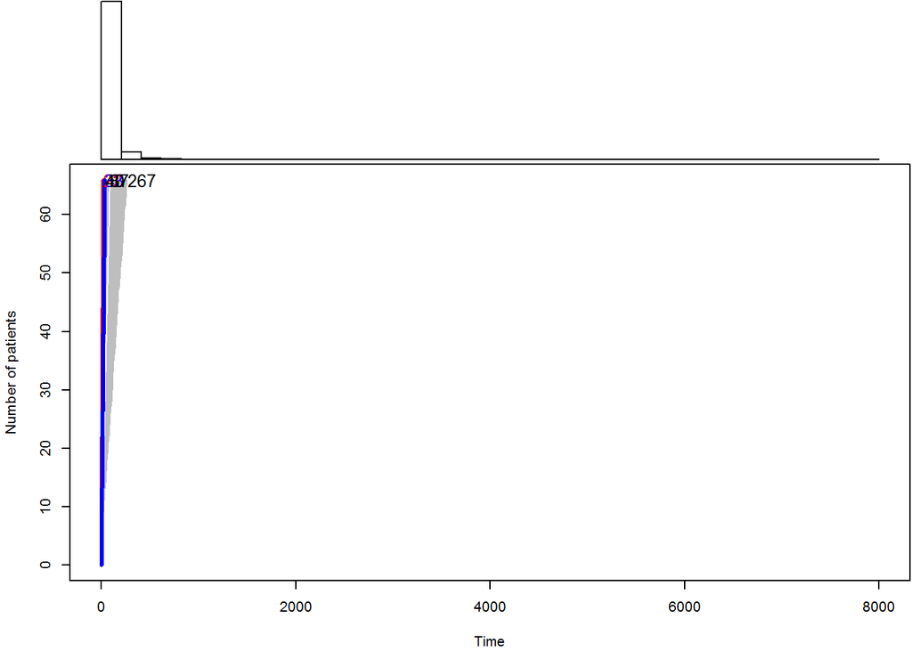

```r
segments(0,0, 22, 66, col="red", lwd=3)
segments(0,0, 33, 66, col="blue", lwd=3)
text(22, 66, "22", col="red", cex=1.25, adj=0)
text(33, 66, "33", col="blue", cex=1.25, adj=0)
text(x5$pct[2, ], 66, round(x5$pct[2, ]), cex=1.25, adj=0)
```

```r
# week=6, total patients=5
x6 <- duration.plot(n=66, T=22, P=0, m=5, tm=6, Tmax=10000)
print(x6$pct)
```

```
##                      2.5%       50%     97.5%
## Waiting time    0.5858466  1.284547   3.69575
## Trial duration 39.0986922 81.763550 226.84601
```

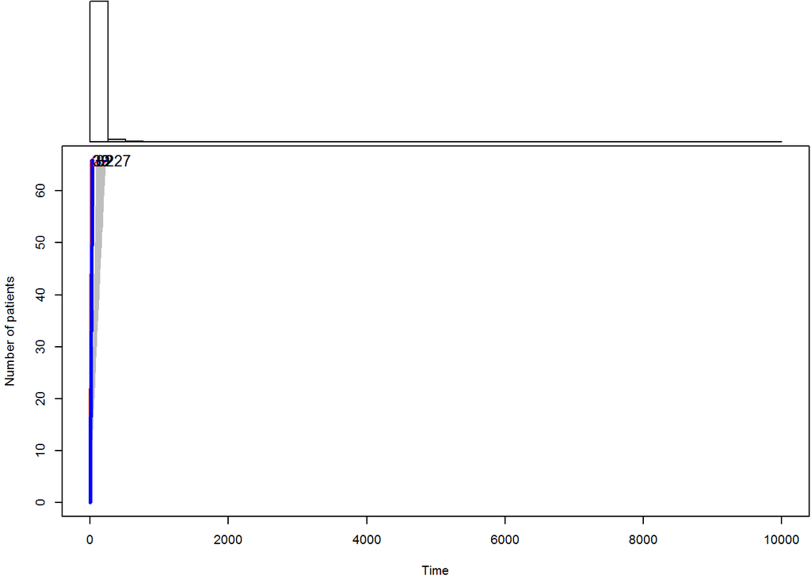

```r
segments(0,0, 22, 66, col="red", lwd=3)
segments(0,0, 33, 66, col="blue", lwd=3)
text(22, 66, "22", col="red", cex=1.25, adj=0)
text(33, 66, "33", col="blue", cex=1.25, adj=0)
text(x6$pct[2, ], 66, round(x6$pct[2, ]), cex=1.25, adj=0)
```

Here’s another accrual data set.

```r
pts <- unlist(read.csv("count.csv"))
# ( qchisq(0.025, 2*x)/2, qchisq(0.975, 2*(x+1))/2 )
x <- cumsum(pts)
lo <- (qchisq(0.025, 2*x)    /2) / (1:length(x))
hi <- (qchisq(0.975, 2*(x+1))/2) / (1:length(x))
lo <- ((1:length(x)) + (350-x)/ lo) / 365
hi <- ((1:length(x)) + (350-x)/ hi) / 365
round(cbind(lo,hi), 2)
```

```
##          lo   hi
## x1    37.77 0.17
## x2    75.54 0.35
## x3    11.82 0.40
## x4    15.76 0.54
## x5    19.70 0.67
## x6    23.63 0.81
## x7    27.57 0.94
## x8    31.51 1.08
## x9    35.45 1.21
## x10   39.39 1.35
## x11   43.33 1.48
## x12   47.27 1.62
## x13   51.21 1.75
## x14   55.15 1.89
## x15   59.09 2.02
## x16   63.03 2.16
## x17   66.96 2.29
## x18   70.90 2.42
## x19   74.84 2.56
## x20   78.78 2.69
## x21   82.72 2.83
## x22   86.66 2.96
## x23   90.60 3.10
## x24   94.54 3.23
## x25   98.48 3.37
## x26  102.42 3.50
## x27  106.36 3.64
## x28  110.29 3.77
## x29   44.64 3.22
## x30   46.18 3.34
## x31   47.72 3.45
## x32   49.26 3.56
## x33   50.80 3.67
## x34   52.34 3.78
## x35   53.88 3.89
## x36   55.42 4.00
## x37   56.96 4.11
## x38   58.50 4.22
## x39   60.04 4.34
```

[output cut: 186 more lines]

```
## x226   8.33 4.52
## x227   8.37 4.54
## x228   7.87 4.36
## x229   7.91 4.38
## x230   7.94 4.40
## x231   7.98 4.42
## x232   8.01 4.44
## x233   8.04 4.46
## x234   7.83 4.38
## x235   7.63 4.31
## x236   7.66 4.33
## x237   7.69 4.34
## x238   7.73 4.36
## x239   7.76 4.38
## x240   7.56 4.31
```

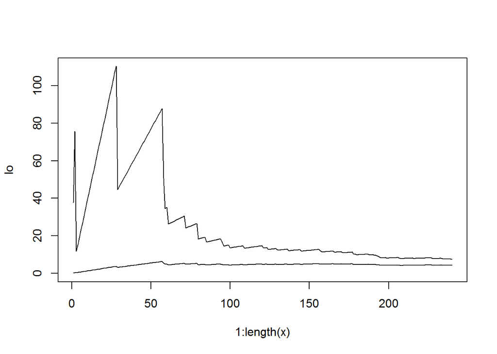

```r
plot(1:length(x),lo, type="l", ylim=c(0, max(lo)))
lines(1:length(x), hi)
```